# Problemas de estadística descriptiva

Bioestadística

Septiembre 2026

## Problema 1: Sinusitis y antibióticos.

Investigadores que estudiaban el efecto del tratamiento con antibióticos para la sinusitis aguda compararon este tratamiento con terapias únicamente sintomáticas. Para ello, asignaron al azar a 166 adultos diagnosticados con sinusitis aguda a uno de dos grupos: tratamiento o control. El grupo de tratamiento recibió un ciclo de 10 días con amoxicilina (un antibiótico). El grupo de control recibió un placebo con el mismo aspecto y sabor, pero consistente en tratamientos sintomáticos habituales como paracetamol, descongestionantes nasales, etc. Al final de los 10 días, se preguntó a los pacientes si habían notado mejoría en sus síntomas. Los resultados se resumen en la siguiente tabla:

| Self-reported improvement in symptoms | Self-reported improvement in symptoms | Self-reported improvement in symptoms Sí | Self-reported improvement in symptoms No | Self-reported improvement in symptoms Total |
| --- | --- | --- | --- | --- |
| Grupo | Tratamiento | 66 | 19 | 85 |
|  | Control | 65 | 16 | 81 |
|  | Total | 131 | 35 | 166 |

Garbutt JM, Banister C, Spitznagel E, Piccirillo JF. Amoxicillin for Acute Rhinosinusitis: A Randomized Controlled Trial. JAMA. 2012;307(7):685–692. doi:10.1001/jama.2012.138

**Preguntas:**

### a) ¿Qué porcentaje de pacientes del grupo de tratamiento informó haber mejorado sus síntomas?

### b) ¿Qué porcentaje informó mejoría en el grupo control?

### c) ¿En qué grupo el porcentaje de pacientes con mejoría fue mayor?

### d) Los resultados podrían hacer pensar que existe una diferencia real en la eficacia entre el antibiótico y el placebo para mejorar los síntomas de la sinusitis. Sin embargo, esta no es la única explicación posible. ¿Qué otra explicación se podría dar a la diferencia observada entre los porcentajes de mejoría en ambos grupos?

## Problema 2: Comportamiento gustativo en colibríes

Investigadores plantearon la hipótesis de que un receptor del sabor en los colibríes, T1R1-T1R3, desempeñaba un papel principal en dictar el comportamiento gustativo; en concreto, en determinar qué compuestos detectan los colibríes como dulces. En una serie de pruebas de campo, se presentaron simultáneamente a los colibríes dos recipientes: uno con el estímulo de prueba (*test stimuli*) y otro con sacarosa. El estímulo de prueba incluyó aspartamo, eritritol, agua y sacarosa. El aspartamo es un edulcorante artificial que sabe dulce para los humanos, pero no es detectado por T1R1-T1R3. El eritritol es un edulcotrante artificial que sí activa T1R1-T1R3.

Se recogieron datos sobre el tiempo que un colibrí bebía de un recipiente, medido en segundos.

**Preguntas:**

### a) ¿Qué pruebas son controles y cuáles tratamientos?

### b) Indentifica las variables de respuesta del estudio. Son numéricas o categóricas?

### c) Describe la pregunta principal de investigación.

## Problema 3: Coloración de huevos

El significado evolutivo de la variación en la coloración de los huevos entre aves no se comprende completamente. Una hipótesis sugiere que la coloración de los huevos puede ser un indicador de la calidad de la hembra: hembras más sanas serían capaces de depositar pigmento azul-verde en la cáscara en lugar de usarlo para sí mismas como antioxidante.

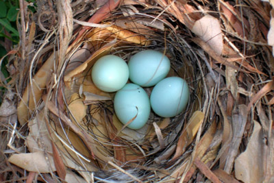

En un estudio realizado con 32 papamoscas cerrojillo (*Ficedula hypoleuca*), a la mitad de las hembras se les proporcionó una dieta suplementaria antes y durante la puesta de huevos. Se midió la oscuridad del color azul de los huevos mediante espectrofotometría; por ejemplo, la cantidad media de croma azul-verde fue de 0.594 unidades de absorbancia. También se registró la masa del huevo.

**Preguntas**

### a) Identifica los grupos control y tratamiento.

### b) Describe la pregunta principal de investigación.

### c) ¿Cuál es la variable de respuesta principal?

## Problema 4: Método Buteyko

El método Buteyko es una técnica de respiración superficial desarrollada por Konstantin Buteyko, un médico ruso, en 1952. Evidencia anecdótica sugiere que el método Buteyko puede reducir los síntomas del asma y mejorar la calidad de vida. En un estudio científico para determinar la efectividad de este método, los investigadores reclutaron 600 pacientes asmáticos de entre 18 y 69 años que dependían de medicación para el tratamiento del asma. Estos pacientes se dividieron aleatoriamente en dos grupos de investigación: uno practicaba el método Buteyko y el otro no.  
A los pacientes se les puntuó la calidad de vida, la actividad, los síntomas de asma y la reducción de medicación en una escala de 0 a 10. En promedio, los participantes del grupo Buteyko experimentaron una reducción significativa de los síntomas de asma y una mejora en la calidad de vida.

73J. McGowan. “Health Education: Does the Buteyko Institute Method make a difference?” In: Thorax 58 (2003).

**Preguntas**

### a) Identifica la pregunta principal de investigación del estudio.

### b) ¿Quiénes son los sujetos de este estudio y cuántos se incluyen?

### c) ¿Cuáles son las variables del estudio? Identifica cada variable como numérica o categórica. Si es numérica, indica si es discreta o continua. Si es categórica, indica si es ordinal.

## Diferencias entre un estudio experimental y observacional

| Característica | Estudio experimental | Estudio observacional |
| --- | --- | --- |
| Control del investigador | Manipula variables (p. ej., asigna tratamientos o intervenciones). | No manipula, solo observa lo que ocurre de manera natural. |
| Aleatorización | Puede asignar aleatoriamente a los sujetos a grupos. | No hay asignación aleatoria. |
| Causalidad | Permite establecer relaciones causales (si está bien diseñado). | Solo permite identificar asociaciones, no causalidad. |
| Ejemplo | Ensayo clínico con un fármaco vs. placebo. | Estudio de la relación entre contaminación ambiental y nacimientos prematuros. |

## Problema 5: Polluelos y antioxidantes.

Los factores ambientales en etapas tempranas de la vida pueden tener efectos duraderos en un organismo. En un estudio, investigadores examinaron si la suplementación dietética con vitaminas C y E influye en la masa corporal y el nivel de corticosterona en polluelos de gaviota patiamarilla. Los polluelos fueron asignados aleatoriamente a un grupo sin suplementación o al grupo experimental con suplemento de vitaminas. El estudio inicial consistió en 108 nidos, con 3 huevos por nido. Los polluelos fueron evaluados a los 7 días de edad.

### a) ¿Qué tipo de estudio es este? ¿Observacional o experimental?

### b) ¿Cuáles son los tratamientos experimental y de control en este estudio?

### c) Explica por qué la aleatorización es una característica importante de este experimento.

## Problema 6: Contaminación del aire y nacimientos prematuros

Investigadores recopilaron datos para examinar la relación entre contaminantes del aire y los nacimientos prematuros en el sur de California. Durante el estudio, los niveles de contaminación del aire se midieron mediante estaciones de control de calidad del aire. En concreto, se registraron los niveles de monóxido de carbono (en partes por millón), dióxido de nitrógeno y ozono (en partes por cien millones), y material particulado grueso (PM10, en µg/m³). Se recopilaron datos sobre la duración de la gestación en 143196 nacimientos ocurridos entre los años 1989 y 1993, y para cada nacimiento se calculó la exposición a la contaminación del aire durante la gestación. El análisis sugirió que un aumento en los niveles ambientales de PM_[10] y, en menor medida, de CO, podría estar asociado con la ocurrencia de nacimientos prematuros. Se puede asumir que los 143.196 nacimientos representan efectivamente la población completa de nacimientos en ese período.

B. Ritz et al. “Effect of air pollution on preterm birth among children born in Southern California between 1989 and 1993”. In: Epidemiology 11.5 (2000), pp. 502–511.

**Preguntas**

### a) Identifica la población de interés y la muestra en este estudio.

### b) Comenta si los resultados del estudio se pueden generalizar a la población y si los hallazgos permiten establecer relaciones causales.

## Problema 7: Ingresos en la cafetería.

El primer histograma (1) presenta la distribución de los ingresos anuales de 40 clientes en una cafetería universitaria. Supongamos que dos personas nuevas entran en la cafetería: una que gana 220000$ y otra que gana 260000$. El segundo histograma (2) muestra la nueva distribución de ingresos, añadiendo esos 2 universitarios. También se proporcionan estadísticas resumidas en la tabla.

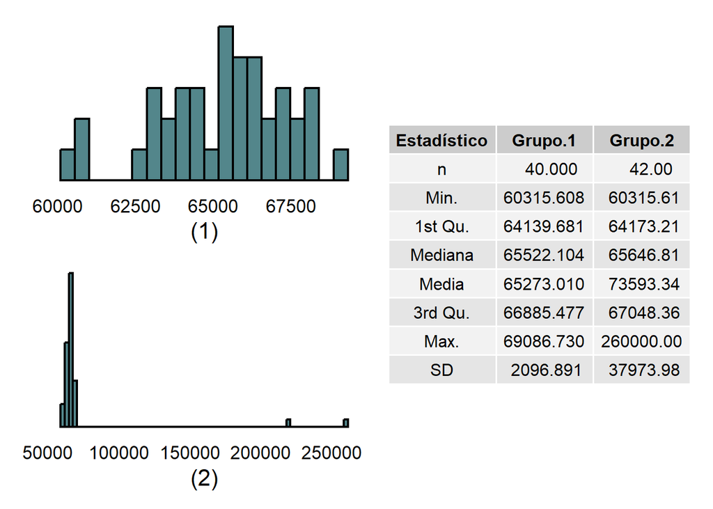

**Preguntas**

### a) ¿Sería mejor la media o la mediana para representar lo que podríamos considerar un ingreso típico para los 42 clientes de esta cafetería? ¿Qué nos dice esto sobre la robustez de ambas medidas?

### b) ¿Sería mejor la desviación típica o el rango intercuartílico (IQR) para representar la cantidad de variabilidad en los ingresos de los 42 clientes de esta cafetería? ¿Qué nos dice esto sobre la robustez de ambas medidas?

## Problema 8: Hábitos de uso del hilo dental.

Supongamos que se entrega un cuestionario anónimo a los pacientes en un consultorio dental cuando llegan a su cita. Una de las preguntas es: “¿Con qué frecuencia usas hilo dental?”, y se proporcionan cuatro opciones de respuesta: a) al menos dos veces al día, b) al menos una vez al día, c) varias veces a la semana, d) varias veces al mes.

Al final de la semana, se registran las respuestas: 31 individuos eligieron la opción a), 55 eligieron la b), 39 eligieron la c) y 12 eligieron la d).

**Preguntas**

### a) Describe cómo se podrían resumir estos datos de forma numérica y gráfica.

**Reto: Haz el gráfico con `ggplot2`** (opcional)

### b) Evalúa si los resultados de esta encuesta pueden generalizarse para proporcionar información sobre los hábitos de uso del hilo dental en la población general.

## Problema 9: Error vs. variabilidad

En estadística, un error no es un “equivocación”. La variabilidad es una parte inherente de los resultados de las mediciones y del proceso de medición. Los errores observados se pueden dividir en dos componentes: error aleatorio y error sistemático. Los errores sistemáticos son errores que no están determinados por el azar, sino que se introducen por una inexactitud (ya sea en la observación o en el proceso de medición) inherente al sistema. Los errores aleatorios están relacionados con el muestreo. Cada medición subsiguiente tiene un error aleatorio, lo que lleva a imprecisión en la estimación. Una medición con bajo error aleatorio se dice que es precisa. En el error sistemático, cada medición subsiguiente tiene el mismo error recurrente debido a un sesgo.

Cuatro analistas, A, B, C y D, prepararon cinco muestras replicadas para medir el pH de una muestra específica de suelo. Los resultados son los siguientes:

| Analista | Med1 | Med2 | Med3 | Med4 | Med5 | Media | SD |
| --- | --- | --- | --- | --- | --- | --- | --- |
| A | 8.208 | 8.239 | 8.258 | 8.264 | 8.283 | 8.2504 | 0.0284306 |
| B | 8.278 | 8.288 | 8.293 | 8.304 | 8.308 | 8.2942 | 0.0121326 |
| C | 8.259 | 8.289 | 8.308 | 8.329 | 8.363 | 8.3096 | 0.0394183 |
| D | 8.389 | 8.393 | 8.399 | 8.413 | 8.423 | 8.4034 | 0.0142408 |

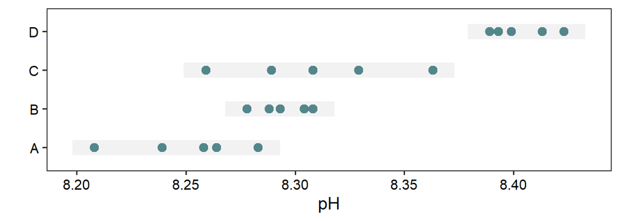

### a) ¿Qué conjunto tiene menor error aleatorio? ¿Cuál tiene el mayor error aleatorio?

### b) ¿Qué conjunto es más preciso? ¿Cuál es menos preciso?

### c) ¿Alguno de los conjuntos probablemente tiene un error sistemático (está sesgado)?

### d) Si se conociera que el valor verdadero es 8.31, ¿qué conjunto sería más exacto?

## Problema 10: Cálculo de parámetros de estadística

A continuación se muestran datos sobre el número de bacterias resistentes a un virus en un estudio experimental: `14, 15, 13, 21, 15, 14, 26, 16, 20, 13`

### a) Determina la mediana y los cuartiles.

### b) Calcula la varianza y la desviación estándard.

### c) Determina el rango intercuartílico.

Los cuartiles son valores que dividen un conjunto de datos ordenados en cuatro partes iguales, cada una conteniendo el 25% de los datos. Existen tres cuartiles principales:

Primer cuartil - Q1: Es el valor que deja el 25% de los datos por debajo de él.

Segundo cuartil (mediana) - Q2: Es la mediana, que divide el conjunto en dos partes iguales (50% por debajo y 50% por encima).

Tercer cuartil - Q3: Es el valor que deja el 75% de los datos por debajo de él.

Estos cuartiles se calculan a partir de la posición de los datos en una distribución ordenada.

Fórmulas para calcular las posiciones de los tres cuartiles:

$$Q1 = \frac{n+1}{4}$$

$$Q2 = \frac{n+1}{2}$$

$$Q3 = \frac{3(n+1)}{4}$$

Si la posición obtenida no es un número entero, se interpola entre los valores cercanos. Si lo es (cuando se tiene un número impar de observaciones), entonces corresponde a la mediana de la primera y segunda mitad de los datos.

*Nota: si calculas Q1 y Q3 en R, es probable que los valores difieran ligeramente de los que obtienes “a mano”. No te preocupes: R utiliza algoritmos de interpolación diferentes a los que usamos manualmente.*

### d) ¿Qué valor tendría que tener una observación en este conjunto de datos para considerarse un valor atípico?